# Problem Set 5

Sara Peters

2023-10-18

###Soc 756

#Measuring Fertility

*Jenna- I had a hard time this week because I kept encountering different formulas for calculating the same thing, and the different formulas would give me very different results. I didn’t get a chance to meet with the study group so in some places I’ve calculated two things and tried to make a interpretation that makes sense to me. I might try to meet with you next week about this because I find it very confusing.*

#1. The dataframe below describes the U.S. population in 1997. The life table values come from a female life table (remember our small correction to eq. 5.18 in the textbook) with a radix of 100,000.

##Create Dataframe

```r
#Population of Females and their associated births as of July 1, 1997.
FemLT_97 <- data.frame(
  x = c(10, 15, 20, 25, 30, 35, 40, 45),
  n = rep(5, times = 8),
  Females = c(9315000, 9302000, 8591000, 9446000, 10447000, 11373000, 10800000, 9409000),
  All_Births = c(10121, 483220, 942048, 1069436, 886798, 409710, 76084, 3333),
  Fem_Births = c(4899, 236207, 460534, 523179, 432638, 200533, 37288, 1617),
  Lx = c(495678, 494913, 493741, 492428, 490757, 488395, 484977, 479969),
  lx = c(99174, 99083, 98868, 98624, 98336, 97945, 97381, 96561)
)

str(FemLT_97)
```

```
## 'data.frame':    8 obs. of  7 variables:
##  $ x         : num  10 15 20 25 30 35 40 45
##  $ n         : num  5 5 5 5 5 5 5 5
##  $ Females   : num  9315000 9302000 8591000 9446000 10447000 ...
##  $ All_Births: num  10121 483220 942048 1069436 886798 ...
##  $ Fem_Births: num  4899 236207 460534 523179 432638 ...
##  $ Lx        : num  495678 494913 493741 492428 490757 ...
##  $ lx        : num  99174 99083 98868 98624 98336 ...
```

```r
print(FemLT_97)
```

```
##    x n  Females All_Births Fem_Births     Lx    lx
## 1 10 5  9315000      10121       4899 495678 99174
## 2 15 5  9302000     483220     236207 494913 99083
## 3 20 5  8591000     942048     460534 493741 98868
## 4 25 5  9446000    1069436     523179 492428 98624
## 5 30 5 10447000     886798     432638 490757 98336
## 6 35 5 11373000     409710     200533 488395 97945
## 7 40 5 10800000      76084      37288 484977 97381
## 8 45 5  9409000       3333       1617 479969 96561
```

```r
#Male and Female Populations
Male = 130783000
Female = 137001000
l0 = 100000
```

#Calculations

```r
#Total births period 0 to T

TB <- sum(FemLT_97$All_Births)

#Person-years lived between 0 and T (total population)
TP <- sum(Male + Female)

#Person-years lived between 0 and T (Females 15-50)
#Mortality considered
LxF <- sum(FemLT_97$Lx)
#Mortality not considered
TPF <- sum(FemLT_97$Females)

#Age specific fertility rate
FemLT_97 = FemLT_97 %>%
  mutate(ASFR = FemLT_97$All_Births/FemLT_97$Females * n)

sum_ASFR <- sum(FemLT_97$ASFR)

#TFR for single ages
FemLT_97 = FemLT_97 %>%
  mutate(TFR_1 = (FemLT_97$All_Births/FemLT_97$Females)/5)

sum_TFR <- sum(FemLT_97$TFR_1)

#maternity rate = female births in the period 0 to T to women age x to x + n/Person-years lived in the period 0 to T by women aged x to x + n, maternity function of age m(a)

FemLT_97 = FemLT_97 %>%
  mutate(ASMR = FemLT_97$Fem_Births/FemLT_97$Females)

sum_ASMR <- sum(FemLT_97$ASMR)

print(TB)
```

```
## [1] 3880750
```

```r
print(TP)
```

```
## [1] 267784000
```

```r
print(LxF)
```

```
## [1] 3920858
```

```r
print(TPF)
```

```
## [1] 78683000
```

```r
print(sum_ASFR)
```

```
## [1] 2.02107
```

```r
print(sum_ASMR)
```

```
## [1] 0.197581
```

*A. What was the Crude Birth Rate in the United States in 1997?*

```r
#Crude birth rate = Births in the period 0 to T/ Person-years lived in the population between time 0 and T

CBR<- ((TB/TP)/5)

print(CBR)* 1000
```

```
## [1] 0.00289842
```

```
## [1] 2.89842
```

*B. What was the General Fertility Rate in the United States in 1997?*

```r
#General fertility rate = Births in the period 0 to T/ Person-years lived in the period 0 to oT by women aged 15 to 50

FemLT_97 = FemLT_97 %>%
  mutate(AS_GFR = ASFR * Females/ TPF)

GFR <- TB/TPF

print(GFR) * 1000
```

```
## [1] 0.0493213
```

```
## [1] 49.3213
```

```r
#GFR is prefered because the denominator is more specific to the population at risk (women giving birth) and it also takes age structure of the population into consideration.

Factor_BR <- CBR/GFR

print(Factor_BR)
```

```
## [1] 0.058766
```

*By what factor does the GFR differ from the CBR and why?* The difference between crude birth rate and general fertility rate is that the GFR calculation is specific to the population of females who could give birth (population at risk) and takes the age-structure of the population into account). In this case the crude birth rate and general fertility rate differ by a factor of 58 per 1000.

*C. Calculate and graph the age-specific fertility rates in the United States in 1997.*

```r
#Age-specific fertility rates = Births in the period 0 to T to women aged x to x + n/ Person-Years lived in the period 0 to T by women aged x to x + n

ASFR_df <- data.frame(ASFR = FemLT_97$ASFR)

print(ASFR_df)
```

```
##         ASFR
## 1 0.00543264
## 2 0.25973984
## 3 0.54827610
## 4 0.56607876
## 5 0.42442711
## 6 0.18012398
## 7 0.03522407
## 8 0.00177118
```

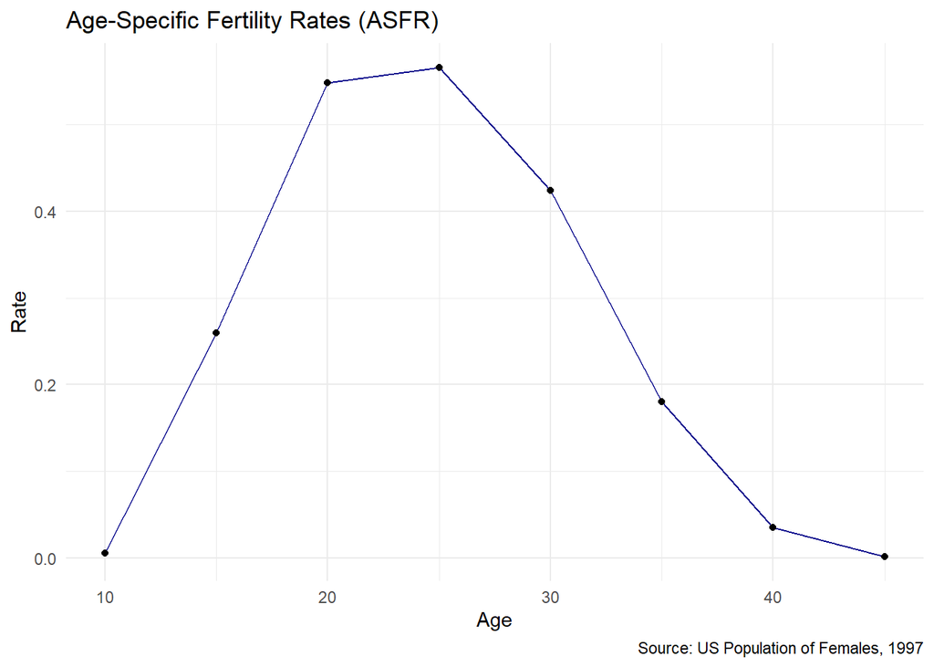

```r
# Plot ASFR
ggplot(data = FemLT_97, aes(x = x, y = ASFR)) +
  geom_line(color = "darkblue") +  # Add a dark blue line
  geom_point() +  # Add points at data values
  labs(
    title = "Age-Specific Fertility Rates (ASFR)",
    x = "Age",
    y = "Rate",
    caption = "Source: US Population of Females, 1997"
  ) +
  theme_minimal()
```

*D. Calculate and interpret the Total Fertility Rate in the United States in 1997.*

```r
#TFR = interval * (Sum of ASFR), ASFR = nFx

TFR = 5 * sum_ASFR

print(TFR)
```

```
## [1] 10.1054
```

```r
TFR_1 = sum_TFR * 5

print(TFR_1)
```

```
## [1] 0.404215
```

*Interpretation*: The period total fertility rate (TFR) is the average number of children a woman would bear if she experienced a given set of age-specific fertility rates at each age of her reproductive years, assuming survival. This calculation is an example of where I was finding different ways of calculating the rate the first is one you provided and the second is another I’ve used in the past which distributes the ASFR over 5 years and then adds the interval back to the sum of the ASFRs. Both don’t seem right to me. In this cohort the average number of children per woman could be 10 OR it be less than 1 (.4), which indicates that not every woman is having a child.

*E. Calculate and interpret the Gross Reproduction Rate (GRR) in the United States in 1997. Assume that the sex ratio of births is invariant to the age of the mother and equal to 1.05.*

```r
#GRR = TFR * 1/ 1+ 1.05 (standard measure of sex ratio at birth)

GRR<- sum_ASMR * 5

print (GRR)
```

```
## [1] 0.987907
```

*Interpretation*: The gross reproduction rate (GRR) is the number of births an average woman would have assuming survival through reproductive years. It does not account for mortality. In this cohort the GRR indicates 0.988 daughter per childbearing person.

*F. Calculate and interpret the Net Reproduction Rate (NRR) in the United States in 1997. Make the same assumption as in E.*

```r
#NRR = n* sum(maternity rate * probability of surviving from birth to age group of mother) = n* sum (nFxf * nLx/l0)

FemLT_97 = FemLT_97 %>%
  mutate(NRR_a = ASMR * Lx)

sum_FB <- sum(FemLT_97$NRR_a)

NRR<- sum_FB/100000

print(NRR)
```

```
## [1] 0.972616
```

*Interpretation*: The net reproduction rate is a realistic measure of reproduction because it takes mortality into account by introducing an nLx term. It is the average number of births to females by a birth cohort during their reproductive years, subject to observed age-specific maternity and mortality rates. A NRR of 1 represents replacement level fertility, NRR is generally smaller than GRR because of the consideration of mortality. In this cohort NRR indicates 0.973 daughters per childbearing person.

*G. How close is your answer in F to the NRR you would approximate by NRR = p(Am) x GRR? What is the value of this approximation?*

```r
#p(Am) = sum (ASMR * (lx/l0))/ sum of ASMR

FemLT_97 = FemLT_97 %>%
  mutate(pAm_a = ASMR * lx/l0)

sum_pAm <- sum(FemLT_97$pAm_a)

pAm <- sum_pAm/ sum_ASMR

print(pAm)
```

```
## [1] 0.986062
```

```r
#NRR = p(Am) * GRR

NRR_pAm <- pAm * GRR

print(NRR_pAm)
```

```
## [1] 0.974137
```

*Interpretation*: The approximation of NRR using p(Am) is 0.974 which is close to the calculation for NRR above and still lower than GRR.

```r
print(FemLT_97)
```

```
##    x n  Females All_Births Fem_Births     Lx    lx       ASFR        TFR_1
## 1 10 5  9315000      10121       4899 495678 99174 0.00543264 0.0002173054
## 2 15 5  9302000     483220     236207 494913 99083 0.25973984 0.0103895936
## 3 20 5  8591000     942048     460534 493741 98868 0.54827610 0.0219310441
## 4 25 5  9446000    1069436     523179 492428 98624 0.56607876 0.0226431505
## 5 30 5 10447000     886798     432638 490757 98336 0.42442711 0.0169770843
## 6 35 5 11373000     409710     200533 488395 97945 0.18012398 0.0072049591
## 7 40 5 10800000      76084      37288 484977 97381 0.03522407 0.0014089630
## 8 45 5  9409000       3333       1617 479969 96561 0.00177118 0.0000708471
##          ASMR      AS_GFR      NRR_a       pAm_a
## 1 0.000525926 0.000643150   260.6899 0.000521582
## 2 0.025393141 0.030706760 12567.3957 0.025160286
## 3 0.053606565 0.059863503 26467.7590 0.052999739
## 4 0.055386301 0.067958517 27273.7655 0.054624186
## 5 0.041412654 0.056352579 20323.5500 0.040723548
## 6 0.017632375 0.026035484  8611.5638 0.017270030
## 7 0.003452593 0.004834844  1674.4280 0.003362169
## 8 0.000171857 0.000211799    82.4859 0.000165947
```

#You may assume that l(x) is linear within the intervals (follows the form l(x)=a+bx) to interpolate the value of l(Am) if needed.

#2. In hypothetical population Tau, the fecund period is 250 months, the fecundability of all women is 0.2 at all ages during the fecund period, the average anovulatory period after pregnancy is 13 months, the duration of aborted pregnancies is 2 months and the post-abortion anovulatory period is 3 months.

#Suppose that eleven possible contraceptive techniques are being considered for a cohort of women. The effectiveness of these techniques range from 0.45 to 0.95 in increments of 0.05.

*Using equation 1, graph the expected TFR by contraceptive effectiveness, both in the absence of abortion and in the presence of a 1:1 ratio of abortions to live births. Graph the percent decrease in the TFR implied by the presence of abortion by contraceptive effectiveness.*

```r
#waiting period = (1/p) + 9 for first birth
#waiting period for subsequent births = (1/p) + 9 + S
#waiting period for contraception use = (1/p(1-e) + 9 + S) where 1-e is contraception effectiveness (divided by 100 if in percentage form)
#waiting period for contraceptive use and abortion = (1/p(1-e) + 9 + S + K((1/p(1-e) + S*) where K is the ratio of abortions to live births and S* is the waiting period after fetal death.

Tau <- data.frame(
  e = c(seq(0.45, 0.95, by = 0.05))
)

L <- 250 #length
p <- 0.2 #fecundability
S_b <- 13 #sterile period with birth
Preg <- 9 #pregnancy
Ab<- 2 #uncompleted pregnancy
S_a = 3 #sterile period with fetal death (abortion)

#TFR without abortions considered
Tau = Tau %>%
  mutate(TFR_na = L/((1/(p*(1-e)) + S_b + Preg)))

#TFR with abortions considered
Tau = Tau %>%
  mutate(TFR_a = L/((1/(p*(1-e)) + S_b + Preg) + (1*((1/(p*(1-e)) + S_a + Ab)))))



#% difference of contraceptive effectivness on TFR when abortions are present vs not
Tau = Tau %>%
  mutate(TFR_diff = (TFR_na- TFR_a)/ TFR_na)


print(Tau)
```

```
##       e  TFR_na   TFR_a TFR_diff
## 1  0.45 8.04094 5.53320 0.311871
## 2  0.50 7.81250 5.31915 0.319149
## 3  0.55 7.55034 5.07901 0.327314
## 4  0.60 7.24638 4.80769 0.336538
## 5  0.65 6.88976 4.49871 0.347044
## 6  0.70 6.46552 4.14365 0.359116
## 7  0.75 5.95238 3.73134 0.373134
## 8  0.80 5.31915 3.24675 0.389610
## 9  0.85 4.51807 2.66904 0.409253
## 10 0.90 3.47222 1.96850 0.433071
## 11 0.95 2.04918 1.10132 0.462555
```

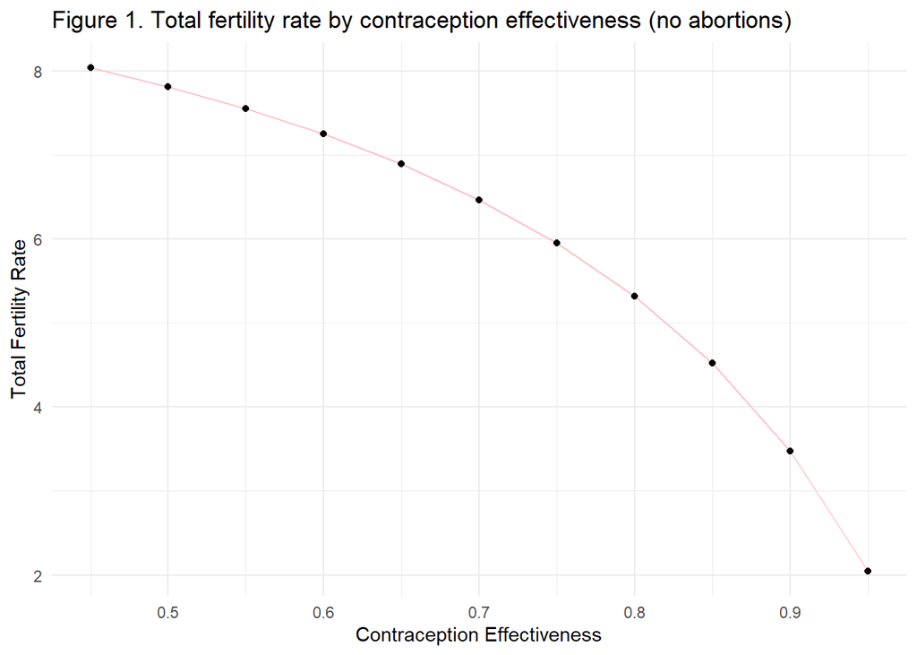

```r
#plot TFR by contraceptive effectiveness in the absence of abortion
ggplot(data = Tau, aes(x = e, y = TFR_na)) +
  geom_line(color = "pink") +
  geom_point() +  # Add points at data values
  labs(
    title = "Figure 1. Total fertility rate by contraception effectiveness (no abortions)",
    x = "Contraception Effectiveness",
    y = "Total Fertility Rate",
  ) +
  theme_minimal()
```

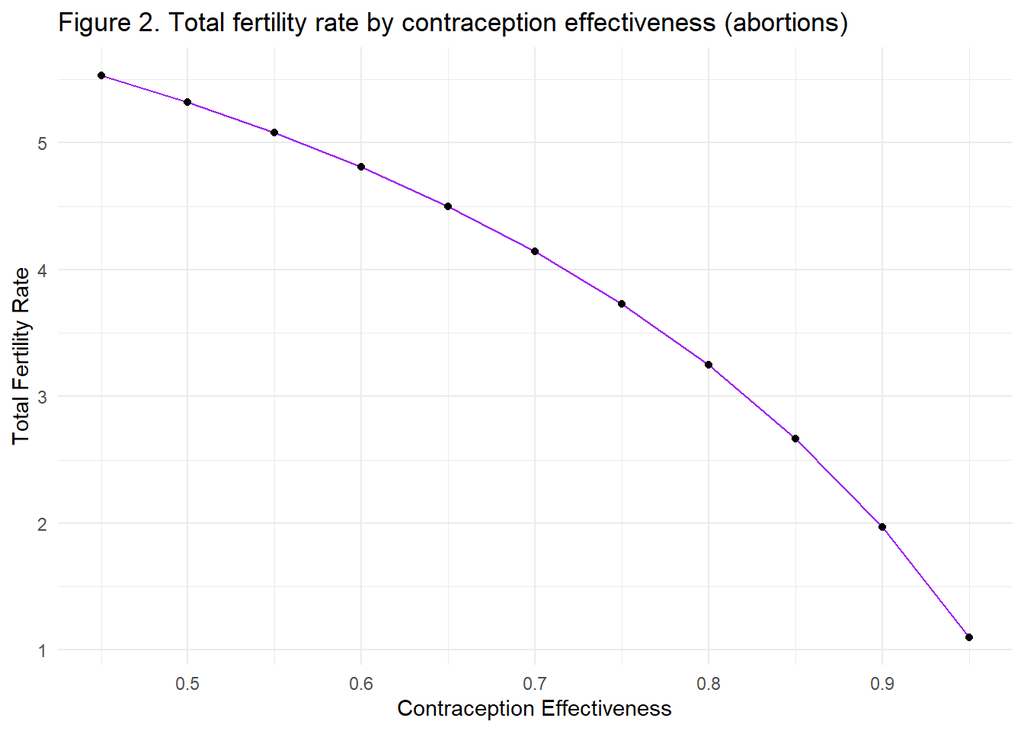

```r
#plot the TFR by contraceptive effectiveness in the presence of 1:1 ratio of abortions to live births
ggplot(data = Tau, aes(x = e, y = TFR_a)) +
  geom_line(color = "purple") +
  geom_point() +  # Add points at data values
  labs(
    title = "Figure 2. Total fertility rate by contraception effectiveness (abortions)",
    x = "Contraception Effectiveness",
    y = "Total Fertility Rate",
  ) +
  theme_minimal()
```

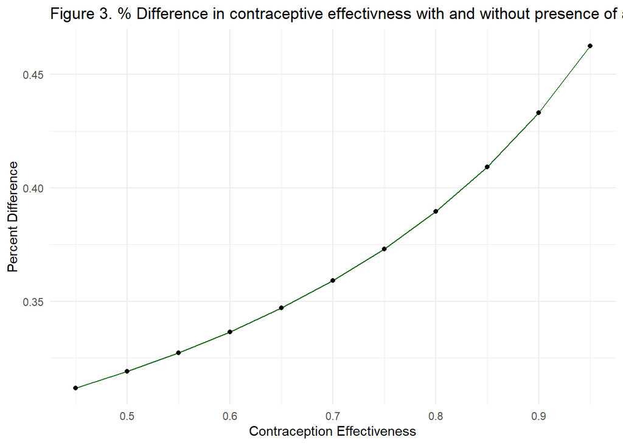

```r
#plot the percept decrease in the TFR implied by the presence of abortion by contraceptive effectiveness


ggplot(data = Tau, aes(x = e, y = TFR_diff)) +
  geom_line(color = "darkgreen") +
  geom_point() +  # Add points at data values
  labs(
    title = "Figure 3. % Difference in contraceptive effectivness with and without presence of abortions ",
    x = "Contraception Effectiveness",
    y = "Percent Difference",
  ) +
  theme_minimal()
```

*Interpret both graphs.*

When abortion is not considered the total fertility rate declines from about 8 to about 2 as the effectiveness of contraception increases from .45 to .95 (*Figure 1*). When abortions are considered, the overall total fertility rate decreases because of the increase of incomplete pregnancies (and subsequent increase of sterile periods). When abortions are considered the TFR declines from about 5.5 to about 1 as the effectiveness of contraception increases from .45 to .95 (*Figure 2*). The percentage difference between the two rates shows that as the effectiveness of contraception increases the bigger the difference between the TFR when there are no abortions and the TFR with abortions. This is because with more effective contraception, incomplete pregnancies have a larger impact on the total fertility rate.